# Loading and Preprocessing the Data

### Filling in the Missing Values

#### (with Average Steps per 5-Minute Interval)

By making the assumption that had the missing data been recorded, it would have measured close to the data that were measured near those times, we can reasonably fill them in and approximate analyses that could have resulted had the data been complete.

First, we'll create a dataframe that has only the rows with missing values in them.

```r
missing<-activity[is.na(activity[,1])|is.na(activity[,2])|is.na(activity[,3]),]

notmissing<-activity[!is.na(activity[,1])&!is.na(activity[,2])&!is.na(activity[,3]),]
```

The above code effectively split the *activity* data frame into two smaller dataframes, *missing* and *notmissing*.

```r
colnames(intervals)<-c("interval","steps")
merged<-merge(missing,intervals,by.x="interval", by.y="interval")
```

By merging the *missing* dataframe with the *intervals* dataframe, we pair off all of the intervals that had “NA” steps with the average total number of steps for the same interval.

Next, we clean up the *merged* dataframe, by removing the column of NA's, and giving names that agree with the original, *activity* dataframe.

```r
merged<-cbind(merged[,1],merged[,3:4])
colnames(merged)<-c("interval","date","steps")

filled<-rbind(merged,notmissing)
```

This allowed us to paste back together the *merged* data frame with the *notmissing* dataframe, giving us a *filled* dataframe, which should be the same as the original, *activity*, except all of the NA's have been replaced with average 5-minute interval values.

##### Graphing the Filled in Data

Now that we have filled in all the NA's, we can graph and see how this compares with the result when we just ignored the NA's

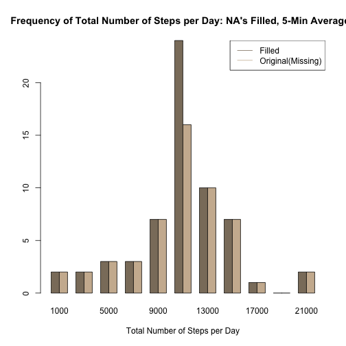

```r
library(plotrix)
filledDay<-aggregate(filled$steps,by=list(filled$date),FUN=sum)
compare<-list(filledDay[,2],Activity[,2])
multhist(compare,main="Frequency of Total Number of Steps per Day: NA's Filled, 5-Min Averages",xlab="Total Number of Steps per Day",col=c("bisque4","bisque3"))
legend("topright",c("Filled","Original(Missing)"),col=c("bisque4","bisque3"),lty=c(1,1))
```

##### Mean of Filled Data

```r
dayMeanFilled<-mean(filledDay[,2])
dayMedianFilled<-median(filledDay[,2])
```

After the NA's are filled with corresponding averages for 5-minute intervales, the **mean** is \(\frac{10766.1886792 \ steps}{day}\), and the **median** is \(\frac{10766.1886792 \ steps}{day}\), compared to the mean before filling NA's, \(\frac{10766.1886792 \ steps}{day}\), and the median, \(\frac{10765 \ steps}{day}\).

## Weekday versus Weekend Activity Patterns

### Creating the *Weekday* Column

In order to compare weekday versus weekend usage, we augment the data with a column that lets us know whether each observation was made on a weekday or a weekend.

We accomplish this by first of all taking our data, *filled*, with the NA's filled in with the 5-minute interval averages, augmenting it with a copy of the “date” column, and renaming that copied column, “weekday”.

```r
filledWeek<-cbind(filled,filled$date)
colnames(filledWeek)[4]<-"weekday"
```

```r
filledWeek$weekday<-weekdays(as.Date(filledWeek$weekday))
```

Nextly, we use the “sub()” function to replace the day name with the category to which it belongs.

```r
filledWeek$weekday<-sub("Monday|Tuesday|Wednesday|Thursday|Friday","weekday",filledWeek$weekday)
filledWeek$weekday<-sub("Saturday|Sunday","weekend",filledWeek$weekday)
filledWeek$weekday<-as.factor(filledWeek$weekday)
```

### Comparing Graphically Weekday to Weekend Activity

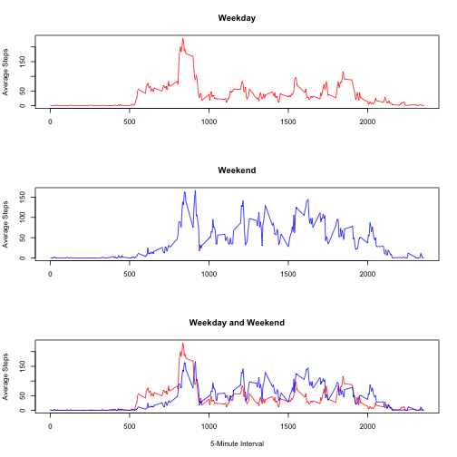

```r
filledWeekIntervals<-aggregate(filledWeek$steps,by=list(filledWeek$interval,filledWeek$weekday),FUN=mean)
filledWeekdayIntervals<-dplyr::filter(filledWeekIntervals,filledWeekIntervals$Group.2 == "weekday")
filledWeekendIntervals<-dplyr::filter(filledWeekIntervals,filledWeekIntervals$Group.2 == "weekend")
par(mfrow=c(3,1))
plot(filledWeekdayIntervals$x~filledWeekdayIntervals$Group.1,xlab="",type="l",main="Weekday",ylab="Average Steps",col="red")
plot(filledWeekendIntervals$x~filledWeekendIntervals$Group.1,xlab="",type="l",main="Weekend",ylab="Average Steps",col="blue")
plot(filledWeekdayIntervals$x~filledWeekdayIntervals$Group.1,type="l",main="Weekday and Weekend",ylab="Average Steps",col="red",xlab="5-Minute Interval")
lines(filledWeekendIntervals$x~filledWeekendIntervals$Group.1,type="l",col="blue",ylab="Average Steps")
```